# Practica 1 - G6

Smart Packaging es una solución innovadora que demuestra el potencial de aplicar tecnología avanzada a los procesos logísticos de empaque. Sin embargo, los inversores de la empresa han expresado preocupación por el incremento constante en los costos energéticos. Uno de los inversores obtuvo información detallada sobre el consumo energético y la exportó en el archivo POE_2023.xlsx, el cual contiene registros del consumo medido en MWh. Este inversor considera que dicha información es clave para evaluar la rentabilidad del negocio. Con base en la construcción de un modelo de análisis, se desea responder a las siguientes preguntas:

# 1. ¿Cuál es el costo actual del consumo energético, considerando que los robots consumen actualmente 0.2 MWh y operan bajo el horario laboral vigente (08:00 a 20:00 horas)?

```r
ARCHIVO_EXCEL <- "POE_2023.xlsx"

# horario laboral: de 8:00 AM a 8:00 PM (20:00 horas)
HORARIO_LABORAL <- 8:20

# días laborales promedio por mes
DIAS_LABORALES_MES <- 30

# Parámetros del problema
CONSUMO_ACTUAL <- 0.2
HORAS_ACTUALES <- 12 #las horas que se trabajan al dia

MESES <- c("ENERO", "FEBRERO", "MARZO", "ABRIL", "MAYO", "JUNIO",
           "JULIO", "AGOSTO", "SEPTIEMBRE", "OCTUBRE", "NOVIEMBRE", "DICIEMBRE")
```

### Calculos

```r
# Calcular los costos mensuales basados en el consumo actual
costos_mensuales <- datos_laborales %>%
  group_by(mes, mes_num) %>%  # Agrupar por mes y número de mes
  summarise(
    precio_promedio = mean(precio_mwh, na.rm = TRUE),
    registros = n(),
    .groups = 'drop'
  ) %>%
  mutate(
    # Precio promedio × Consumo por hora × Horas por día × Días por mes
    costo_mensual_actual = precio_promedio * CONSUMO_ACTUAL * HORAS_ACTUALES * DIAS_LABORALES_MES
  ) %>%
  arrange(mes_num)

# Calcular el costo total anual sumando todos los costos mensuales
costo_anual_actual <- sum(costos_mensuales$costo_mensual_actual)

costo_avg_hora <- mean(datos_laborales$precio_mwh)
```

### RESPUESTA 1

```r
cat("\nCOSTO ACTUAL DEL CONSUMO ENERGÉTICO\n", "Costo anual total:", scales::dollar(costo_anual_actual), "\n", "Costo mensual promedio:", scales::dollar(costo_anual_actual/12), "\n", "Costo hora promedio:", scales::dollar(costo_avg_hora), "\n")
```

[output not shown]

# 2. Si se modifica el modelo para que los robots consuman 0.15 MWh, pero trabajen la mitad del tiempo, ¿sigue siendo rentable la operación?

```r
CONSUMO_NUEVO <- 0.15
HORAS_NUEVAS <- HORAS_ACTUALES / 2
```

### Calculos

```r
costos_mensuales_nuevos <- costos_mensuales %>%
  mutate(
  costo_mensual_nuevo = precio_promedio * CONSUMO_NUEVO * HORAS_NUEVAS * DIAS_LABORALES_MES,
  ahorro_mensual = costo_mensual_actual - costo_mensual_nuevo,
    porcentaje_ahorro = (ahorro_mensual / costo_mensual_actual) * 100
  )

costo_anual_nuevo <- sum(costos_mensuales_nuevos$costo_mensual_nuevo)
ahorro_anual <- costo_anual_actual - costo_anual_nuevo
porcentaje_ahorro_anual <- (ahorro_anual / costo_anual_actual) * 100
```

### RESPUESTA 2

```r
cat("\nRENTABILIDAD DEL NUEVO MODELO\n", "Costo anual actual:", scales::dollar(costo_anual_actual), "\n", "Costo anual propuesto:", scales::dollar(costo_anual_nuevo), "\n", "Ahorro anual:", scales::dollar(ahorro_anual), "\n", "Porcentaje de ahorro:", round(porcentaje_ahorro_anual, 1), "%\n")
```

```
##
## RENTABILIDAD DEL NUEVO MODELO
##  Costo anual actual: $103,824
##  Costo anual propuesto: $38,934.16
##  Ahorro anual: $64,890.27
##  Porcentaje de ahorro: 62.5 %
```

```r
cat(" El modelo propuesto genera ahorros superiores al 60%\n")
```

```
##  El modelo propuesto genera ahorros superiores al 60%
```

# 3. Los inversores desean identificar el mes más rentable y el mes menos rentable. Esta información debe presentarse en:

## Una tabla comparativa mensual.

```r
tabla_comparativa <- costos_mensuales_nuevos %>%
  mutate(
    Mes = mes,
    `Precio Promedio ($/MWh)` = round(precio_promedio, 2),
    `Costo Actual ($)` = round(costo_mensual_actual, 0)
  ) %>%
  select(Mes, `Precio Promedio ($/MWh)`, `Costo Actual ($)`)

print(tabla_comparativa)
```

```
## # A tibble: 12 × 3
##    Mes        `Precio Promedio ($/MWh)` `Costo Actual ($)`
##    <chr>                          <dbl>              <dbl>
##  1 ENERO                           80.7               5808
##  2 FEBRERO                         88.1               6341
##  3 MARZO                          125.                8966
##  4 ABRIL                          126.                9085
##  5 MAYO                           181.               13026
##  6 JUNIO                          184.               13247
##  7 JULIO                          122.                8796
##  8 AGOSTO                         116.                8335
##  9 SEPTIEMBRE                     104.                7465
## 10 OCTUBRE                        109.                7825
## 11 NOVIEMBRE                      107.                7715
## 12 DICIEMBRE                      100.                7217
```

## Una gráfica ordenada por mes, que permita visualizar tendencias de aumento o disminución en la rentabilidad.

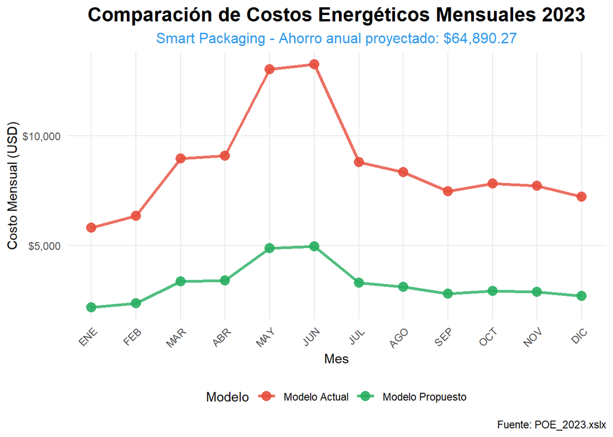

```r
datos_grafico <- costos_mensuales_nuevos %>%
  select(mes, mes_num, costo_mensual_actual, costo_mensual_nuevo, precio_promedio, ahorro_mensual) %>%
  pivot_longer(cols = c(costo_mensual_actual, costo_mensual_nuevo),
               names_to = "modelo", values_to = "costo") %>%
  mutate(
    modelo = case_when(
      modelo == "costo_mensual_actual" ~ "Modelo Actual",
      modelo == "costo_mensual_nuevo" ~ "Modelo Propuesto"
    ),
    mes_abrev = factor(substr(mes, 1, 3),
                       levels = substr(MESES, 1, 3))
  )

grafico_costos <- ggplot(datos_grafico, aes(x = mes_num, y = costo, color = modelo)) +
  geom_line(size = 1.2, alpha = 0.8) +
  geom_point(size = 3.5, alpha = 0.9) +
  scale_x_continuous(breaks = 1:12, labels = substr(MESES, 1, 3)) +
  scale_y_continuous(labels = scales::dollar_format()) +
  scale_color_manual(
    values = c("Modelo Actual" = "#E74C3C", "Modelo Propuesto" = "#27AE60"),
    name = "Modelo"
  ) +
  labs(
    title = "Comparación de Costos Energéticos Mensuales 2023",
    subtitle = paste("Smart Packaging - Ahorro anual proyectado:", scales::dollar(ahorro_anual)),
    x = "Mes",
    y = "Costo Mensual (USD)",
    caption = "Fuente: POE_2023.xslx"
  ) +
  theme_minimal() +
  theme(
    plot.title = element_text(size = 16, face = "bold", hjust = 0.5),
    plot.subtitle = element_text(size = 12, hjust = 0.5, color = "#349beb"),
    legend.position = "bottom",
    panel.grid.minor = element_blank(),
    axis.text.x = element_text(angle = 45, hjust = 1)
  )
print(grafico_costos)
```

```r
# Filtrar los datos del mes de ENERO
enero_data <- datos %>%
  filter(mes == "ENERO")

# Función para calcular el costo total según las horas activas
calcular_costo_esquema <- function(horas_activas) {
  enero_data %>%
    filter(hora %in% horas_activas) %>%
    summarise(costo_total = sum(precio_mwh * 0.2)) %>%
    pull(costo_total)
}

# Definir horas activas por alternativa
horas_a <- c(4:11, 16:23)       # a) descansa 00-04 y 12-16
horas_b <- c(0:7, 12:15, 20:23) # b) descansa 08-12 y 16-20
horas_c <- c(0:7, 12:19)        # c) descansa 08-12 y 20-24

# Calcular costos por alternativa
costo_a <- calcular_costo_esquema(horas_a)
costo_b <- calcular_costo_esquema(horas_b)
costo_c <- calcular_costo_esquema(horas_c)

# Crear tabla comparativa
df_costos <- data.frame(
  Alternativa = c("a) 00-04 & 12-16", "b) 08-12 & 16-20", "c) 08-12 & 20-24"),
  Horas_Operativas = c(length(horas_a), length(horas_b), length(horas_c)) * 31,  # enero tiene 31 días
  Consumo_Total_MWh = round(c(length(horas_a), length(horas_b), length(horas_c)) * 31 * 0.2, 2),
  Costo_Total_USD = round(c(costo_a, costo_b, costo_c), 2)
)

# Mostrar tabla
df_costos
```

| Alternativa | Horas_Operativas | Consumo_Total_MWh | Costo_Total_USD |
| --- | --- | --- | --- |
| a) 00-04 & 12-16 | 496 | 99.2 | 7591.42 |
| b) 08-12 & 16-20 | 496 | 99.2 | 7331.06 |
| c) 08-12 & 20-24 | 496 | 99.2 | 8631.88 |

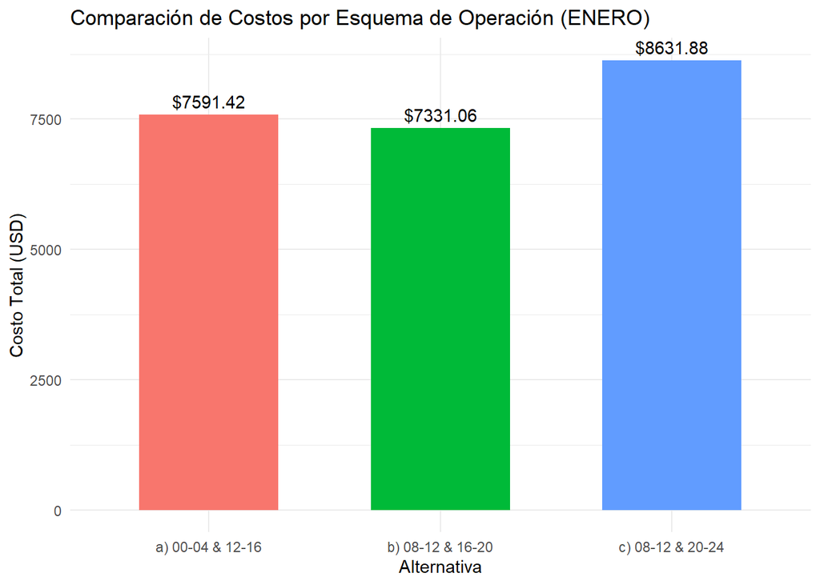

```r
library(ggplot2)

ggplot(df_costos, aes(x = Alternativa, y = Costo_Total_USD, fill = Alternativa)) +
  geom_col(width = 0.6) +
  geom_text(aes(label = paste0("$", round(Costo_Total_USD, 2))), vjust = -0.5) +
  labs(
    title = "Comparación de Costos por Esquema de Operación (ENERO)",
    x = "Alternativa",
    y = "Costo Total (USD)"
  ) +
  theme_minimal() +
  theme(legend.position = "none")
```

Conclusión Las tres alternativas propuestas mantuvieron el mismo consumo total, pero el costo varió según el horario operado. La opción b) fue la más económica, lo que demuestra que operar en horas con menor tarifa puede reducir costos sin afectar la productividad.

## 5. Enriquecimiento de la información

El presente análisis evalúa el consumo energético de Smart Packaging durante el año 2023, enriqueciendo los datos originales con variables contextuales clave para una mejor comprensión de los patrones de consumo y su impacto en la rentabilidad del negocio.

```
## # A tibble: 1 × 7
##   total_registros consumo_promedio consumo_mediano consumo_min consumo_max
##             <int>            <dbl>           <dbl>       <dbl>       <dbl>
## 1            9855             105.            105.       0.875        453.
## # ℹ 2 more variables: desviacion_std <dbl>, consumo_total_anual <dbl>
## # A tibble: 4 × 5
##   tipo_dia       registros consumo_promedio consumo_total desviacion_std
##   <chr>              <int>            <dbl>         <dbl>          <dbl>
## 1 Viernes             1296            114.        147252.           55.0
## 2 Semana Laboral      5508            111.        612279.           54.2
## 3 Fin de Semana       2727             93.7       255459.           45.7
## 4 Feriado              324             72.3        23413.           38.7
## # A tibble: 4 × 5
##   estacion  registros consumo_promedio consumo_total desviacion_std
##   <chr>         <int>            <dbl>         <dbl>          <dbl>
## 1 Primavera      2484            129.        319710.           49.0
## 2 Invierno       2484            125.        310279.           56.6
## 3 Otoño          2457             85.4       209819.           42.5
## 4 Verano         2430             81.7       198595.           42.0
##
## === ANÁLISIS POR PERÍODO DEL DÍA ===
## # A tibble: 3 × 5
##   periodo_dia registros consumo_promedio consumo_total desviacion_std
##   <chr>           <int>            <dbl>         <dbl>          <dbl>
## 1 Madrugada        8395            106.        893736.           52.0
## 2 <NA>             1095            106.        115642.           58.7
## 3 Mañana            365             79.5        29024.           38.5
```

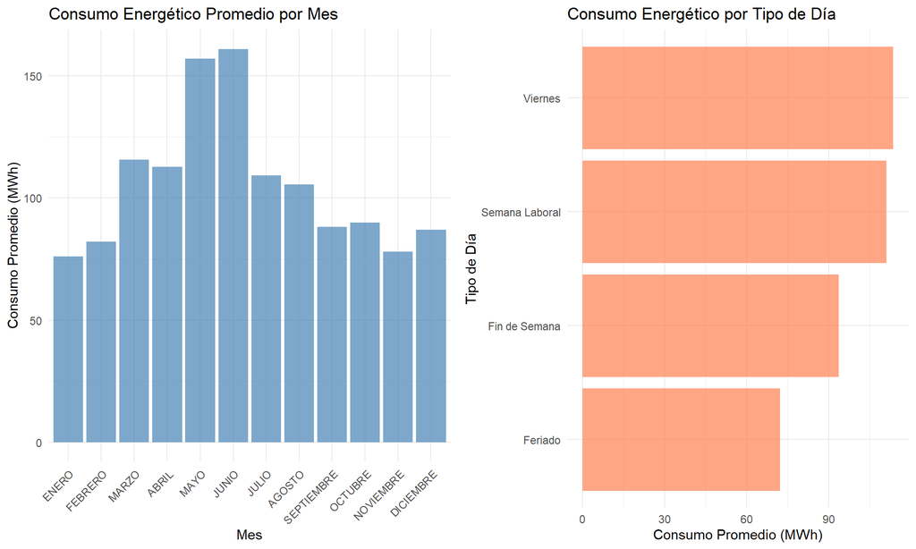

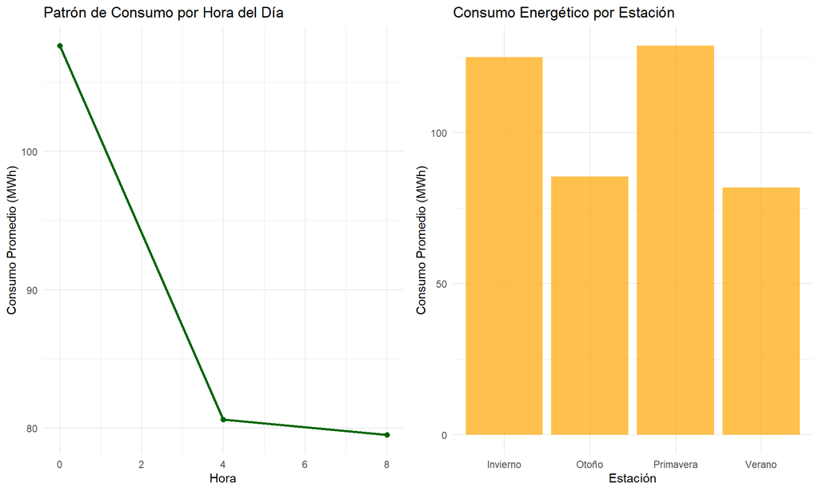

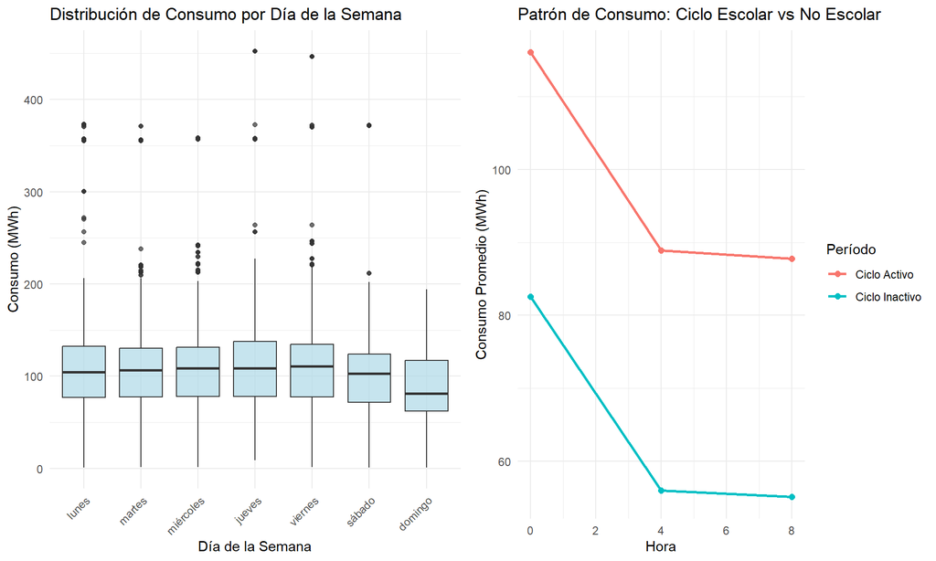

[output not shown]